# Case Study - Fitness and Health Tracking Analysis

#### Analyze – Trends by Intensity of Activity by Week

**2. How consistent did users meet weekly target exercise intensity minutes?**

Based on the [National Health Interview Survey](https://www.healthypeople.gov/2020/topics-objectives/topic/physical-activity/national-snapshot) and [CDC: Physical Activity](https://www.cdc.gov/physicalactivity/basics/adults/index.htm), healthy targets minutes of weekly exercise by different intensities for adults are:

- 150+ minutes/week - light or moderate activity
- 75+ minutes/week - vigorous activity (or, very active)

I analyzed minutes per week by intensity by first converting the dates to week number and week dates. Then, I filtered daily activity data for a three week period between Sunday, April 17, 2016 and Saturday, May 07, 2016.

I grouped the data by user Id2 and week and calculated the sums of distances, calories, and minutes. To match the target rates, I combined light and moderate distances into a separate column and did the same with minutes.

To group dates into week numbers and week dates, I referenced the [aweek package](https://cran.r-project.org/web/packages/aweek/aweek.pdf). I converted each week number into the week date of the Sunday of that week, marking the week’s starting date.

```r
#View(d.activity)

# Convert date to week number
ow <- set_week_start("Sunday") # set start day of week

# function for extracting week number from date and converting to week date
fn.wkNumber <- function(dt) {
dt$week <- date2week(dt$date)
dt$week2 <- sub(".$", "1", dt$week)
dt$week_date <- week2date(dt$week2)  # convert week to Sunday date
return(dt)
}

# apply week number / week date function to d.activity
d.activity <- fn.wkNumber(d.activity)

# filter data for three week period
d.activity_fil <- d.activity %>% filter(between(date, as.Date("2016-04-17"), as.Date("2016-05-07")))
#View(d.activity_fil)

d.activity_fil %>% group_by(week_date) %>%
  summarize(n()) %>% glimpse()  # 3 weeks
```

```
## Rows: 3
## Columns: 2
## $ week_date <date> 2016-04-17, 2016-04-24, 2016-05-01
## $ `n()`     <int> 224, 223, 204
```

```r
# Sum distances, minutes, calories by week and Id2. Combine Light and Moderate into single column (FairlyActiveMinutes is equivalent to Moderate).
wkTotals.activity <- d.activity_fil %>%
  group_by(week_date, Id2) %>%
  summarize(wkDistance = sum(TotalDistance), wkTrackerDistance = sum(TrackerDistance), wkSteps = sum(TotalSteps),
            wkCalories = sum(Calories), VeryActiveDistance = sum(VeryActiveDistance), LightModerateDistance = sum(LightActiveDistance) + sum(ModeratelyActiveDistance),
            VeryActiveMinutes = sum(VeryActiveMinutes),
            LightModerateMinutes = sum(LightlyActiveMinutes) + sum(FairlyActiveMinutes))
# determine if week minute totals meet healthy exercise targets
wkTotals.activity <- wkTotals.activity %>%
  mutate(VeryMin_target = case_when(VeryActiveMinutes <= 75 ~ "no", VeryActiveMinutes >=75 ~ "yes"),
         LightModMin_target = case_when(LightModerateMinutes < 150 ~ "no", LightModerateMinutes >=150 ~ "yes"))

#View(wkTotals.activity)

# determine % of weeks each user is consistent
wkTargets.activity <- wkTotals.activity %>% group_by(Id2) %>%
  summarize(LM_target = sum(LightModMin_target == "yes"),
            V_target = sum(VeryMin_target == "yes"))

#View(wkTargets.activity)

# group by light-moderate and very active targets, calculate count and percents, then bind separate data sets together
numUsers.LM <- wkTargets.activity %>% group_by(LM_target) %>%
  summarize(count_users = n()) %>% mutate(pcts_users = round((count_users / 32), digits=2), activity = "light or moderate")

numUsers.LM <- rename(numUsers.LM, wk_count = "LM_target")
#View(numUsers.LM)

numUsers.V <- wkTargets.activity %>% group_by(V_target) %>%
  summarize(count_users = n()) %>% mutate(pcts_users = round((count_users / 32), digits=2), activity = "very")


numUsers.V <- rename(numUsers.V, wk_count = "V_target")

numUsers.wkActivity <- bind_rows(numUsers.LM, numUsers.V)
#View(numUsers.wkActivity)
```

#### Share – Weekly Activity Target Times

In the bar graph, over three quarters of users achieved the weekly goal of 150+ minutes of light-to-moderate exercise per week for all three weeks. Around 30% of users exercised more than 75+ minutes per week for all three weeks, while about 30% of users had 0 weeks.

Based on this sample, most people meet the weekly exercise recommendations for light-to-moderate exercise, while very active exercise is more variable among users.

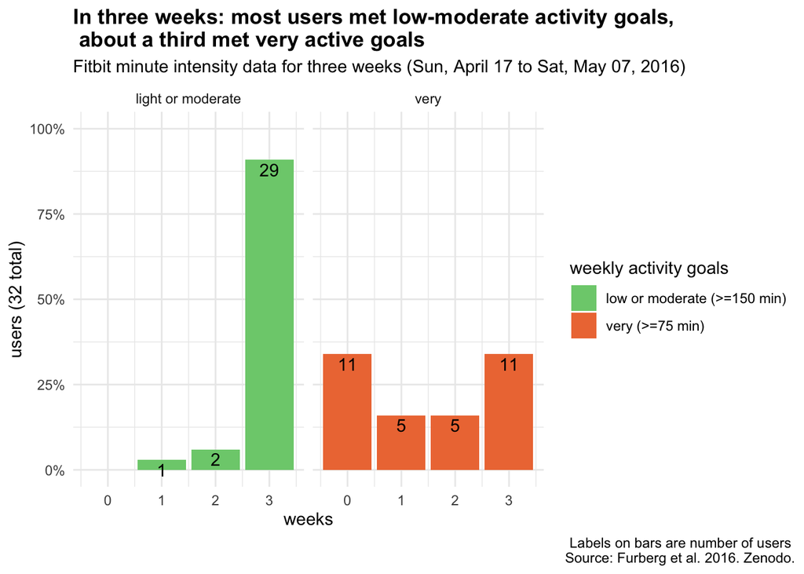

```r
# visualize percentage results in bar grpah, facet wrap by activity type
bar.wkActivity <- numUsers.wkActivity %>%
  ggplot(aes(x = wk_count, y = pcts_users)) +
  geom_bar(aes(fill=activity), stat="identity") +
  geom_text(aes(label = count_users), vjust=1.3) +
  ggtitle("In three weeks: most users met low-moderate activity goals, \n about a third met very active goals") +
  scale_y_continuous(labels=scales::label_percent(accuracy=1)) +
  scale_fill_manual(values = c("palegreen3", "sienna2"), labels= c("low or moderate (>=150 min)", "very (>=75 min)")) +
  labs(subtitle = "Fitbit minute intensity data for three weeks (Sun, April 17 to Sat, May 07, 2016)", x = "weeks", y = "users (32 total)", caption = "Labels on bars are number of users \nSource: Furberg et al. 2016. Zenodo.", fill = "weekly activity goals") +
  theme_minimal() +
  theme(plot.caption.position="plot",
        plot.title= element_text(face="bold")) +
  facet_wrap(~activity) +
  coord_cartesian(ylim = c(0, 1))

bar.wkActivity
```

```r
# ggsave("./plots/bar.wkActivity.png" , width = 8, height = 5, dpi=300)
```

### Analyze – Intensity Minute Trends

**3. Minutes of Different Intensity Exercise and Calories**

Building on step 2, I grouped users by whether or not they had a majority of weeks (at least 2 out of 3 weeks) of light-moderate exercise and/or very-active exercise. For instance, LMV means that user exercised enough for at least 2 weeks, meeting both light-moderate and very active exercise weekly target minutes.

On adding regression lines to scatter plots, I referred to “Basic R Guide for NSC Statistics” by Deanna Li, [Chapter 19: Scatterplots and Best Fit Lines - Two Sets](https://bookdown.org/dli/rguide/scatterplots-and-best-fit-lines-two-sets.html).

```r
#View(wkTargets.activity)

userTypes.intensity <- wkTargets.activity %>%
  mutate(user_type = case_when(LM_target >= 2 & V_target >= 2 ~ "LMV",
                               LM_target < 2 & V_target < 2 ~ "not active",
                               LM_target >= 2 & V_target < 2 ~ "LM",
                               LM_target < 2 & V_target >= 2 ~ "V"))

userTypes <- userTypes.intensity %>% select(Id2, user_type)

userTypes %>% group_by(user_type) %>% summarize(count = n()) %>% glimpse()
```

```
## Rows: 3
## Columns: 2
## $ user_type <chr> "LM", "LMV", "not active"
## $ count     <int> 15, 16, 1
```

```r
#View(userTypes)


# left join wkTotals.activity and userTypes
wkTotals.activity <- merge(x = wkTotals.activity, y = userTypes, by="Id2", all.x=TRUE)

wkTotals.activity <- wkTotals.activity %>% mutate(TotalActiveMinutes = VeryActiveMinutes + LightModerateMinutes)

#View(wkTotals.activity)
```

#### Share – Weekly Intensity Minute Trends

[figure not shown]

```r
# overview of users and intensity minutes and calories
scatter.wkMinutes <- wkTotals.activity %>%
  ggplot(aes(x=LightModerateMinutes, y = VeryActiveMinutes, color = user_type)) +
  geom_point(aes(size = wkCalories, alpha =wkCalories)) +
  geom_hline(yintercept = 75, linetype="dashed", color="red") +
  geom_vline(xintercept = 150, linetype = "dashed", color = "red") +
  ggtitle("Weekly very active vs. light-or-moderate exercise, and calories burned") +
  scale_color_manual(values = c("palegreen3", "sienna2", "lightgoldenrod2"), labels= c("low or moderate", "low, moderate, or very", "not active")) +
  scale_x_continuous(breaks=seq(0, 2700, 400)) +
  labs(subtitle = "Fitbit minute intensity data for three weeks (Sun, April 17 to Sat, May 07, 2016)", x = "light-moderate active minutes", y= "very active minutes", size = "calories", alpha = "calories", color = "type of exerciser", caption = "Dotted lines are weekly activity goals \nSource: Furberg et al. 2016. Zenodo.") +
  theme_minimal() +
  theme(plot.caption.position = "plot",
        plot.title= element_text(face="bold"))
scatter.wkMinutes
```

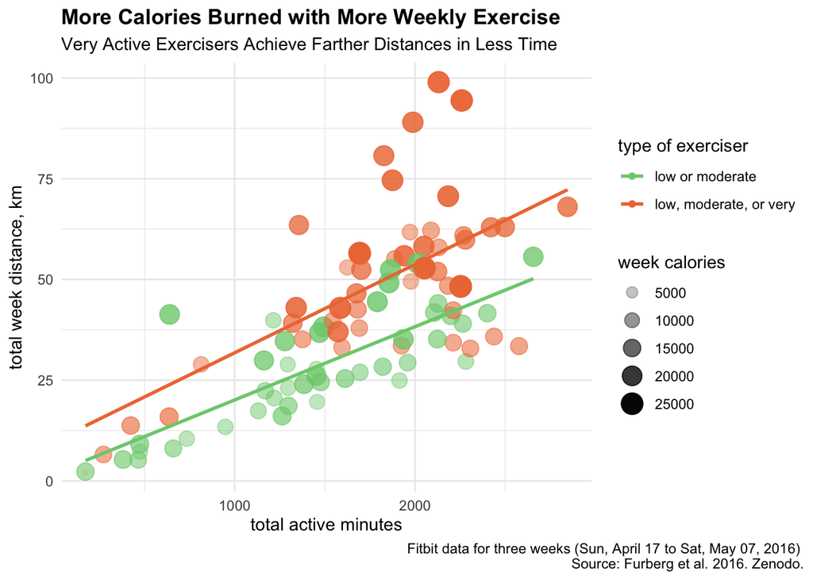

```r
# ggsave("./plots/scatter.wkMinutes.png" , width = 8, height = 5, dpi=300)

# plotting weekly distance and minutes by user type, filter out "not active" users
scatter.wkDistanceMinutes <- wkTotals.activity %>% filter(user_type != "not active") %>%
  ggplot(aes(x=TotalActiveMinutes, y = wkDistance)) +
  geom_point(aes(color = user_type, alpha = wkCalories, size = wkCalories)) +
  geom_smooth(method="lm", se = FALSE, aes(color = user_type), alpha = 0.2) +
  scale_color_manual(values = c("palegreen3", "sienna2"), labels= c("low or moderate", "low, moderate, or very")) +
  ggtitle("More Calories Burned with More Weekly Exercise") +
  labs(subtitle="Very Active Exercisers Achieve Farther Distances in Less Time", x = "total active minutes", y = "total week distance, km", size = "week calories", alpha = "week calories", color = "type of exerciser", caption = "Fitbit data for three weeks (Sun, April 17 to Sat, May 07, 2016) \nSource: Furberg et al. 2016. Zenodo.") +
  theme_minimal() +
  theme(plot.caption.position = "plot",
        plot.title= element_text(face="bold"))
scatter.wkDistanceMinutes
```

```r
# ggsave("./plots/scatter.wkDistanceMinutes.png" , width = 8, height = 5, dpi=300)
```

The first scatter plot shows each weekly observation by the minutes of light-moderate active minutes and very active minutes, with the calories represented as size of the data point. Colors represent the type of exercise that each user frequently meets target weekly minutes for.

In the second scatter plot, very active users (LMV) spend more total active minutes and distance exercising per week than (LM) users who aren’t very intense exercisers. More weekly active minutes is positively correlated with weekly distance, and both are correlated with greater expense of weekly calories.

### Hourly Activity Data

#### Prepare – Merge hourly activity datasets

**1. Merging and filtering steps, calories, intensity [sci] data**

Looking at the other data sets beyond daily activity, I noticed I could combine the data in hourly calories, hourly steps, and hourly intensity into one data frame. I then filtered the data to only hours when people are regularly moving and exercising, between 6 AM and 9 PM, and again, for dates between a three week period, Sunday, April 17, 2016 and Saturday, May 07, 2016.

```r
#View(h.calories)
#View(h.steps)
#View(h.intensities)

fn.countId <- function(dt) {
  dt <- dt %>% count(Id)
  return(glimpse(dt))
}

fn.countId(h.calories) %>% glimpse() #33
```

```
## Rows: 33
## Columns: 2
## $ Id <dbl> 1503960366, 1624580081, 1644430081, 1844505072, 1927972279, 2022484…
## $ n  <int> 717, 736, 708, 731, 736, 736, 736, 735, 414, 736, 472, 696, 732, 88…
## Rows: 33
## Columns: 2
## $ Id <dbl> 1503960366, 1624580081, 1644430081, 1844505072, 1927972279, 2022484…
## $ n  <int> 717, 736, 708, 731, 736, 736, 736, 735, 414, 736, 472, 696, 732, 88…
```

```r
#View(sc)
# steps + calories
sc <- merge(h.steps, h.calories, by=c("Id","ActivityHour"))
# steps + calories + intensities
sci <- merge(sc, h.intensities, by=c("Id","ActivityHour"))
sci <- merge(sci, Id.new, by="Id", all.x=TRUE) # add Id2
#View(sci)


# set timezone
Sys.setenv(tz="America/New_York")
Sys.timezone()
```

```
## [1] "America/New_York"
```

```r
# convert ActivityHour to datetime format
sci$datetime <-strptime(sci$ActivityHour, "%m/%d/%Y %I:%M:%S %p")

# extract hour of day from time, isolate hour
fn.extractHr <- function(dt){
  dt$date <- as.Date(dt$datetime, format="%m/%d/%Y")
  dt$time <- as.POSIXct(dt$datetime, format="%H:%M %p")
  dt$hour <- format(dt$time, format="%I %p")
  dt$hour_min <- format(dt$time, format="%I:%M %p")
  return(dt)
}


sci <- fn.extractHr(sci)
#View(sci)
sci$Day <- weekdays(sci$date)

# range of hours when most people are moving (not sleeping)
amHrs <- paste(6:9, "AM", sep=" ")
amHrs <- paste0(0, amHrs)
midHrs <- paste(10:11, "AM", sep=" ")
pmHrs <- paste(1:9, "PM", sep=" ")
pmHrs <- paste0(0, pmHrs)
movingHrs <- c(amHrs, midHrs, "12 PM", pmHrs)
#glimpse(movingHrs)

# filter sci data for select hours and filter for dates between
sci_fil <- sci %>% filter(hour %in% movingHrs) %>% filter(between(date, as.Date("2016-04-17"), as.Date("2016-05-07")))
#View(sci_fil)


# examine Id2 in sci_fil - Does it match users in userTypes? YES
Id.sci_fil <- sci_fil %>% group_by(Id2) %>% summarize(count = n()) # 32 users
#View(Id.sci_fil)
#View(userTypes)

testIdmatch <- merge(x=Id.sci_fil, y = userTypes, by="Id2", all.x = TRUE )
#View(testIdmatch)

# merge sci with userTypes
sci_fil <- merge(x=sci_fil, y=userTypes, by="Id2", all.x = TRUE )
```

#### Analyze – Group data by hour and day

**2. What hours of each day are people exercising?**

After prepping the combined hourly steps, calories, and intensity [sci_fil] for analysis, I analyzed activity trends by hour of day to see when users were exercising the most and found mean averages for each measurement.

```r
#View(sci_fil)

fn.hourDay.avgs <- function(dt) {
  dt <- dt %>% group_by(hour, Day) %>%
    summarize(avgStepTotal = mean(StepTotal), avgCalories = mean(Calories),
            avgTotalIntensity = mean(TotalIntensity)) %>%
  mutate(across(where(is.numeric), round))
  return(dt)
}

sciAvgs.DayHour <- fn.hourDay.avgs(sci_fil)
#View(sciAvgs.DayHour)
```

#### Share – Intensity heatmaps by hour and day of week

I plotted the hourly activity data [sci], using different heatmaps. When making the heatmaps, I referenced Yan Holtz’s [the R Graph Gallery’s heatmap tutorial](https://www.r-graph-gallery.com/79-levelplot-with-ggplot2.html), as well as the [post on RColorBrewer’s palettes](https://www.r-graph-gallery.com/38-rcolorbrewers-palettes.html), which was helpful in selecting the colors for the heatmaps.

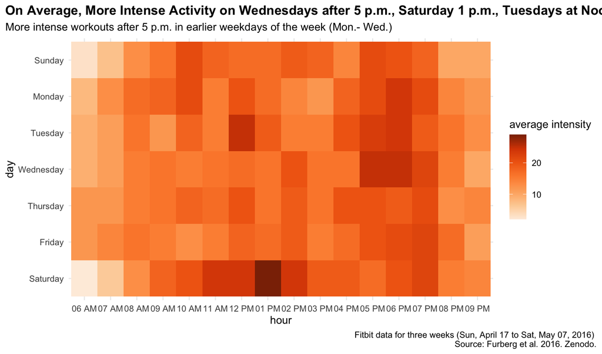

```r
# Overall average total intensities by hour and day of the week
heat.DayHour.intensity <- sciAvgs.DayHour %>% ggplot(aes(x = hour, y=Day, fill=avgTotalIntensity)) +
  geom_tile() +
  ggtitle("On Average, More Intense Activity on Wednesdays after 5 p.m., Saturday 1 p.m., Tuesdays at Noon") +
  labs(fill = "average intensity", subtitle="More intense workouts after 5 p.m. in earlier weekdays of the week (Mon.- Wed.)", caption = "Fitbit data for three weeks (Sun, April 17 to Sat, May 07, 2016) \nSource: Furberg et al. 2016. Zenodo.", y="day") +
  scale_x_discrete(limits= movingHrs) +
  scale_y_discrete(limits= rev(li.daysofwk)) +
  scale_fill_distiller(palette="Oranges", direction =1) +
  theme_minimal() +
  theme(plot.caption.position = "plot",
        plot.title.position = "plot",
        plot.title= element_text(face="bold"))

heat.DayHour.intensity
```

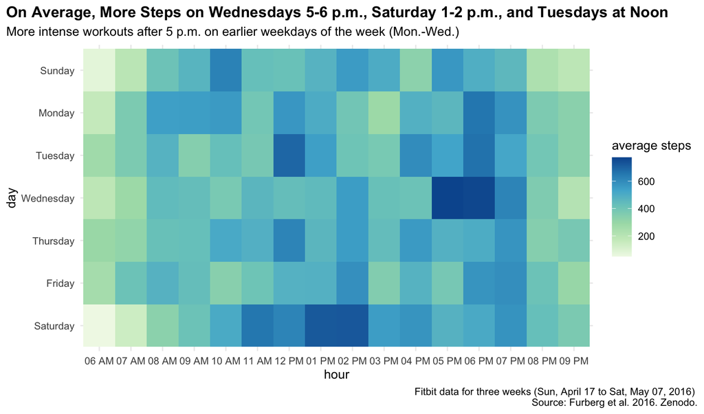

```r
# ggsave("./plots/heat.DayHour.intensity.png" , width = 10.5 , height = 7, dpi=300)

# Overall average total steps by hour and day of the week
heat.DayHour.steps <- sciAvgs.DayHour %>% ggplot(aes(x = hour, y=Day, fill=avgStepTotal)) +
  geom_tile() +
  ggtitle("On Average, More Steps on Wednesdays 5-6 p.m., Saturday 1-2 p.m., and Tuesdays at Noon") +
  labs(fill = "average steps", subtitle="More intense workouts after 5 p.m. on earlier weekdays of the week (Mon.-Wed.)", caption = "Fitbit data for three weeks (Sun, April 17 to Sat, May 07, 2016) \nSource: Furberg et al. 2016. Zenodo.", y="day") +
  scale_x_discrete(limits= movingHrs) +
  scale_y_discrete(limits= rev(li.daysofwk)) +
  scale_fill_distiller(palette="GnBu", direction =1) +
  theme_minimal() +
  theme(plot.caption.position = "plot",
        plot.title.position="plot",
        plot.title= element_text(face="bold"))
heat.DayHour.steps
```

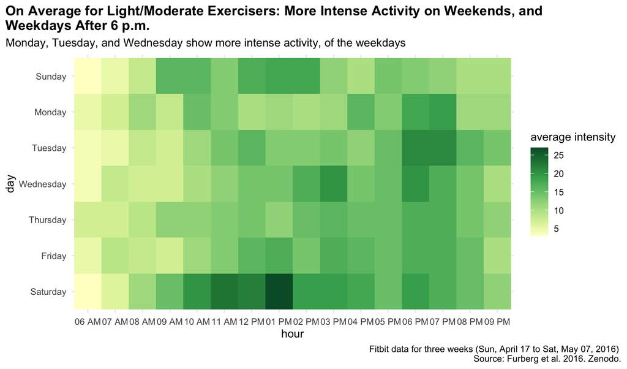

```r
# ggsave("./plots/heat.DayHour.steps.png" , width = 10.5 , height = 7, dpi=300)

# separate data by userType
avgsByHours_LM <- sci_fil %>% filter(user_type == "LM") %>% fn.hourDay.avgs()
#View(avgsByHours_LM)

avgsByHours_LMV <- sci_fil %>% filter(user_type == "LMV") %>% fn.hourDay.avgs()
#View(avgsByHours_LMV)


# for frequent light-moderate exercisers only - average total intensities by hour and day of week
heat.LM.intensity <- avgsByHours_LM %>%
  ggplot(aes(x = hour, y = Day, fill=avgTotalIntensity)) +
  geom_tile() +
  ggtitle("On Average for Light/Moderate Exercisers: More Intense Activity on Weekends, and \nWeekdays After 6 p.m.") +
  labs(fill = "average intensity", subtitle="Monday, Tuesday, and Wednesday show more intense activity, of the weekdays", caption = "Fitbit data for three weeks (Sun, April 17 to Sat, May 07, 2016) \nSource: Furberg et al. 2016. Zenodo.", y="day") +
  scale_y_discrete(limits= rev(li.daysofwk)) +
  scale_x_discrete(limits=movingHrs) +
  scale_fill_distiller(palette="YlGn", direction =1) +
  theme_minimal() +
  theme(plot.caption.position = "plot",
        plot.title.position = "plot",
        plot.title= element_text(face="bold"))
heat.LM.intensity
```

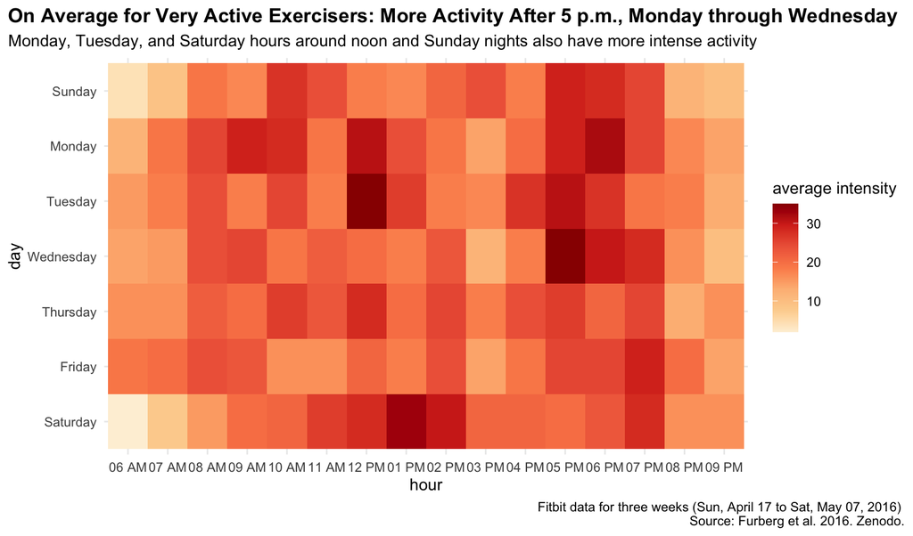

```r
# ggsave("./plots/heat.LM.intensity.png", width = 10.5 , height = 7, dpi=300)

# frequent light-moderate-very active exercisers - average total intensities by hour and day of week
heat.LMV.intensity <- avgsByHours_LMV %>%
  ggplot(aes(x = hour, y = Day, fill=avgTotalIntensity)) +
  geom_tile() +
  ggtitle("On Average for Very Active Exercisers: More Activity After 5 p.m., Monday through Wednesday") +
  labs(fill = "average intensity", subtitle="Monday, Tuesday, and Saturday hours around noon and Sunday nights also have more intense activity", caption = "Fitbit data for three weeks (Sun, April 17 to Sat, May 07, 2016) \nSource: Furberg et al. 2016. Zenodo.", y="day") +
  scale_y_discrete(limits= rev(li.daysofwk)) +
  scale_x_discrete(limits=movingHrs) +
  scale_fill_distiller(palette="OrRd", direction =1) +
  theme_minimal() +
  theme(plot.caption.position = "plot",
        plot.title.position = "plot",
        plot.title = element_text(face="bold"))
heat.LMV.intensity
```

```r
# ggsave("./plots/heat.LMV.intensity.png" , width = 10.5 , height = 7, dpi=300)
```

#### Key Findings – Hourly Activity

Based on the Fitbit hourly exercise heatmaps, I would suggest the following to improve Bellabeat Time:

- Provide a questionnaire for users in the tracking app to ask what kind of exercise intensity they intend on doing on a weekly basis (very, moderate, or light activity) and suggest optimal exercise hours based on hourly trends of Fitbit users, grouped by exercise intensity type.
- As weekdays after 5 p.m. and weekend afternoons are on average more popular intense activity workout times, giving users the option to create an hourly exercise schedule, including setting reminders to exercise at certain times of the day could improve consistency of workouts.

## Sleep Tracking

#### Prepare – Clean sleep tracking data

**1. Cleaning the sleep data** The original sleepDay only has data for 24 users. This small sample size, being < 30, is a limitation of the data analysis.

First, I wanted to see how consistently each user logged their sleep minutes over a period of time. Again, I performed the usual preparation steps, assigning Id2 to each Id for easier readability and joining the daily activity data with the sleep data.

When cleaning the data, I found three users with duplicate data for the same dates. I removed these duplicate rows before plotting the data.

```r
# merge sleepDay and d.activity
#View(sleepDay)
#View(d.activity)
sleepDay$date <- as.Date(sleepDay$SleepDay, format="%m/%d/%Y")
sleepDay <- merge(x=sleepDay, y=Id.new, by="Id", all.x = TRUE )
#glimpse(sleepDay) # 413 rows

sleepDay_sel <- sleepDay %>% select(TotalSleepRecords: Id2)

sleepId <- sleepDay_sel %>% group_by(Id2) %>% summarize(n()) %>% glimpse()
```

```
## Rows: 24
## Columns: 2
## $ Id2   <chr> "A", "C", "D", "E", "G", "H", "I", "L", "M", "O", "P", "Q", "R",…
## $ `n()` <int> 25, 4, 3, 5, 28, 1, 15, 28, 8, 26, 24, 28, 5, 28, 31, 26, 18, 3,…
```

```r
#View(sleepId)

sleepDates <- sleepDay_sel %>% group_by(date) %>% summarize(n()) %>% glimpse()
```

```
## Rows: 31
## Columns: 2
## $ date  <date> 2016-04-12, 2016-04-13, 2016-04-14, 2016-04-15, 2016-04-16, 201…
## $ `n()` <int> 13, 14, 13, 17, 14, 12, 10, 14, 15, 15, 13, 15, 13, 13, 14, 14, …
```

```r
#View(sleepDates)

# check sleep data for count by date and user Id2
sleepTest <- sleepDay_sel  %>% group_by(date, Id2) %>% summarize(count = n()) %>% arrange(desc(count))
#View(sleepTest)

## Id2: P, S, ZD each have 2 entries for same date (duplicate data)
sleepTest2 <- sleepDay_sel %>% filter( Id2 == "ZD" & date == as.Date("2016-04-25") | Id2 == "P" & date == as.Date("2016-05-05") |
                                          Id2 == "S" & date== as.Date("2016-05-07"))
# View(sleepTest2)

# remove duplicated rows in sleep data
sleepDay_sel <- sleepDay_sel %>% distinct() %>% glimpse() # 410 rows
```

```
## Rows: 410
## Columns: 5
## $ TotalSleepRecords  <dbl> 1, 2, 1, 2, 1, 1, 1, 1, 1, 1, 1, 1, 1, 1, 1, 1, 1, …
## $ TotalMinutesAsleep <dbl> 327, 384, 412, 340, 700, 304, 360, 325, 361, 430, 2…
## $ TotalTimeInBed     <dbl> 346, 407, 442, 367, 712, 320, 377, 364, 384, 449, 3…
## $ date               <date> 2016-04-12, 2016-04-13, 2016-04-15, 2016-04-16, 20…
## $ Id2                <chr> "A", "A", "A", "A", "A", "A", "A", "A", "A", "A", "…
```

```r
# merge sleep and activity data
sleepActivity <- merge(x=sleepDay_sel, y=d.activity, by=c("Id2", "date"), all.x=TRUE)

# add columns for total minutes of exercise
sleepActivity <- sleepActivity %>% mutate(LightModMinutes = (LightlyActiveMinutes + FairlyActiveMinutes)) %>%
  mutate(TotalActiveMinutes = (VeryActiveMinutes + LightModMinutes))

#View(sleepActivity)
# add exercise intensity type of each user
sleepActivity.userTypes <- merge(x = sleepActivity, y = userTypes, by = "Id2", all.x=TRUE)

#(sleepActivity.userTypes)
```

### Daily Sleep Records

#### Analyze – Consistency of sleep records per user

Again, I filtered the daily sleep data to three weeks. I wanted to see how consistent users were recording their sleep time, so I counted the total number of date entries for each user.

```r
# filter data for three week period
sleepActivity.userTypes_fil <- sleepActivity.userTypes %>% filter(between(date, as.Date("2016-04-17"), as.Date("2016-05-07")))

#View(sleepActivity.userTypes_fil)
# How consistent is the data?
## How many days each user logged sleep data?
sleepUsers <- sleepActivity.userTypes_fil %>% group_by(Id2) %>% summarize(num_days=n()) %>% glimpse() # 23 users
```

```
## Rows: 23
## Columns: 2
## $ Id2      <chr> "A", "C", "D", "E", "G", "H", "I", "L", "M", "O", "P", "Q", "…
## $ num_days <int> 17, 3, 2, 2, 18, 1, 12, 21, 4, 18, 17, 18, 4, 18, 21, 19, 15,…
```

```r
#View(sleepUsers)

## count how many users logged how many days
sleep.dateCount <- sleepUsers %>% ungroup() %>% group_by(num_days) %>% summarize(user_count=n())

userCount <- sleep.dateCount %>% summarize(totalUsers = sum(user_count))
#glimpse(userCount)
```

#### Share – Visualize user percentage by number of days

The bar graph shows the proportion of 23 users that logged their sleep data for how many days of the selected three weeks. Only 4 users (around 18%) logged sleep minutes for all 21 days.

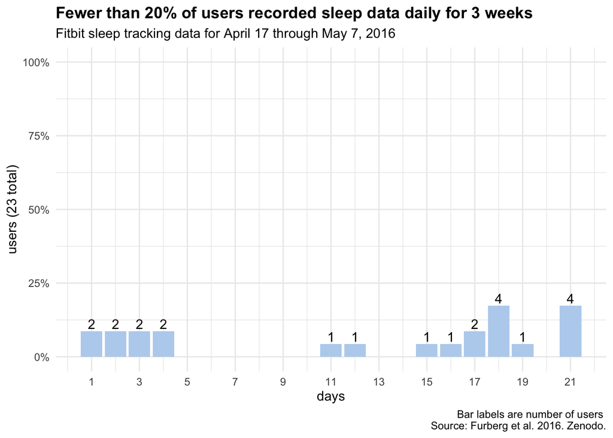

```r
# plot to show percentage of users and record of sleep data over time

bar.sleep.dates <- sleep.dateCount %>% ggplot(aes(x=num_days, y = user_count/ sum(user_count))) +
  geom_bar(stat="identity", fill = "slategray2") +
  geom_text(aes(label = user_count), vjust=-.25) +
  ggtitle("Fewer than 20% of users recorded sleep data daily for 3 weeks") +
  labs( x = "days", y = "users (23 total)", subtitle="Fitbit sleep tracking data for April 17 through May 7, 2016", caption="Bar labels are number of users \nSource: Furberg et al. 2016. Zenodo.") +
  scale_x_continuous(breaks=seq(1, 21, 2)) +
  scale_y_continuous(labels=scales::label_percent(accuracy=1)) +
  coord_cartesian(ylim=c(0, 1)) +
  theme_minimal() +
  theme(plot.title = element_text(face="bold"))

bar.sleep.dates
```

```r
# ggsave("./plots/bar.sleep.dates.png" , width = 9 , height = 7, dpi=300)
```

Bar graph references:

- Thomas Neitmann’s [blogpost about percentage scales](https://thomasadventure.blog/posts/ggplot2-percentage-scale/) was a helpful explainer on how to use the scales package. Note that percent() and percent_format() are retired, according to the [scales package documentation](https://cran.r-project.org/web/packages/scales/scales.pdf), so I used label_percent() instead.
- To adjust the y-axis scale limits to show 0 to 100%, I used coord_cartesian(). To read more about this, see roelpi’s [blog post](https://www.roelpeters.be/add-percentages-to-your-axes-in-rs-ggplot2-and-set-the-limits/) about adding percentage limits using ggplot2
- I referred to a [Stack Overflow discussion](https://stackoverflow.com/questions/12018499/how-to-put-labels-over-geom-bar-for-each-bar-in-r-with-ggplot2) for adding labels to bars in ggplot2, namely the response from user rcs to adjust the placement using vjust.

#### Key Findings – Sleep Records

The lack of consistent daily sleep logging among Fitbit users shows a problematic trend. Perhaps users are not wearing their tracking watches while they sleep. * I suggest that the Bellabeat team create a wearable sleep tracking ring, which some companies like [Oura](https://ouraring.com) have designed. This could act as a companion to the Time watch, and the smaller device might encourage more people to wear a tracker when sleeping. * Providing daily reminders to wear the watch while sleeping, through the Bellabeat app, could help promote consistency of sleep tracking data collection.

### Healthy Daily Sleep

#### Analyze – Target sleep day percentages VS. user percentages

**2. How often do Fitbit users get enough daily sleep?**

According to a 2015 study, [Watson et al](http://dx.doi.org/10.5665/sleep.4716), cited by the [CDC](https://www.cdc.gov/sleep/about_sleep/how_much_sleep.html), the healthy amount of sleep for an adult is 7 hours or more a night. Since the sleep data is in minutes, this converts to 420+ minutes a night.

I categorized each day as >= 420 min. or < 420 min. to determine each user’s percentage of total days of sleep records. By grouping the data further, I found the total count of users and the percentage of healthy days of the sleep days recorded per user.

Next, I grouped the percentage of healthy sleep data into percent ranges by quarters and recounted the total users per percent range and the respective user percentages. This data is easier to visualize than individual non-grouped healthy sleep day percentages.

```r
# For each user, how often did they get a healthy amount of sleep?
#View(sleepActivity.userTypes_fil)

healthy.sleepDays <- sleepActivity.userTypes_fil %>%
  mutate(sleepTarget = case_when(TotalMinutesAsleep >= 420 ~ "healthy",
                                 TotalMinutesAsleep < 420 ~ "no"))

## percentages by number of days they recorded sleep data
healthy.sleepDays.byUser <- healthy.sleepDays %>% group_by(Id2) %>%
  summarize(healthy_sleep_days = sum(sleepTarget == "healthy"),
            total_days = n()) %>%
  mutate(pct_healthy_sleep = round(healthy_sleep_days / total_days, digits=2))

#View(healthy.sleepDays.byUser)

## group by percentages of healthy sleep days to find user counts and percentages
healthy.sleepDays.pctUsers <- healthy.sleepDays.byUser %>% group_by(pct_healthy_sleep) %>%
  summarize(count_user = n()) %>%
  mutate(pct_user = round( count_user / sum(count_user), digits=2)) %>% ungroup()
glimpse(healthy.sleepDays.pctUsers)
```

```
## Rows: 16
## Columns: 3
## $ pct_healthy_sleep <dbl> 0.00, 0.12, 0.25, 0.28, 0.33, 0.45, 0.52, 0.57, 0.58…
## $ count_user        <int> 5, 1, 1, 1, 2, 1, 1, 1, 1, 1, 2, 1, 1, 1, 1, 2
## $ pct_user          <dbl> 0.22, 0.04, 0.04, 0.04, 0.09, 0.04, 0.04, 0.04, 0.04…
```

```r
sum(healthy.sleepDays.pctUsers$count_user) #23 total users
```

```
## [1] 23
```

```r
ranges.healthySleepDays.pctUsers <- healthy.sleepDays.pctUsers %>%
  mutate( ranges_sleepDays = dplyr::case_when( pct_healthy_sleep >= 0.75 ~ "75-100%",
                    pct_healthy_sleep >= 0.50 ~ "50-74%",
                     pct_healthy_sleep >= 0.25 ~ "25-49%",
                    pct_healthy_sleep > 0 ~ "0-24%"))

# replace NA with 0-24%
ranges.healthySleepDays.pctUsers[is.na(ranges.healthySleepDays.pctUsers)] = c("0-24%")

ranges.healthySleepDays.pctUsers <- ranges.healthySleepDays.pctUsers %>%
  select(!pct_user) %>%
  group_by(ranges_sleepDays) %>%
  summarize(count_user = sum(count_user)) %>% ungroup() %>%
  mutate(pct_user = round( count_user / sum(count_user), digits=2)) %>% ungroup()

#View(ranges.healthySleepDays.pctUsers)
```

#### Share – Visualize target sleep day percentages by users

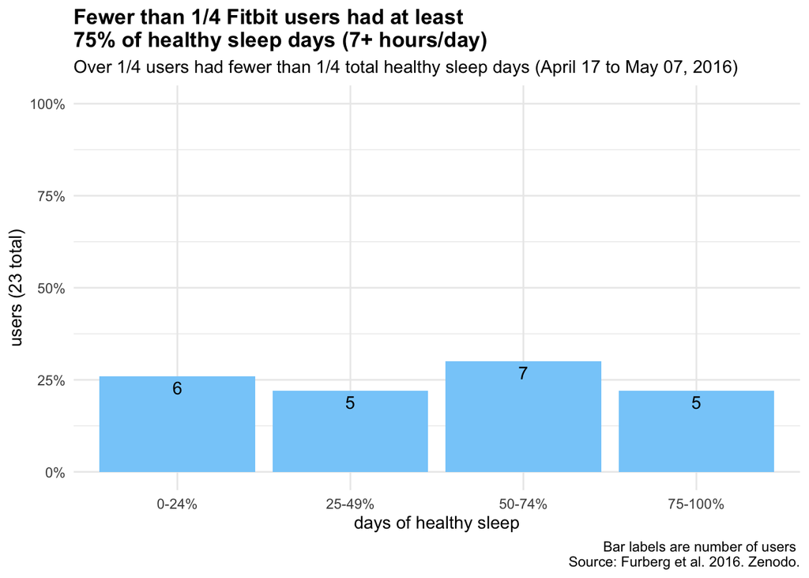

```r
bar.pctHealthySleepDays <- ranges.healthySleepDays.pctUsers %>%
  ggplot(aes(x = ranges_sleepDays, y = pct_user)) +
  geom_bar(stat="identity", fill="lightskyblue") +
  geom_text(aes(label = count_user), vjust = 1.4) +
  ggtitle("Fewer than 1/4 Fitbit users had at least \n75% of healthy sleep days (7+ hours/day)") +
  labs(x = "days of healthy sleep", y="users (23 total)", subtitle="Over 1/4 users had fewer than 1/4 total healthy sleep days (April 17 to May 07, 2016)", caption = "Bar labels are number of users \nSource: Furberg et al. 2016. Zenodo.") +
  scale_y_continuous(labels=scales::label_percent(accuracy=1)) +
  scale_x_discrete() +
  theme_minimal() +
  theme(plot.caption.position = "plot",
        plot.title= element_text(face="bold")) +
  coord_cartesian(ylim = c(0, 1))
bar.pctHealthySleepDays
```

```r
# ggsave("./plots/bar.pctHealthySleepDays.png" , width = 10, height = 7, dpi=300)
```

#### Key Findings – Suggestions for More Healthy Sleep Days

As nearly half of the Fitbit users had fewer than 50% healthy sleep days of their total sleep records, another sleep data trend is that most people are not sleeping the healthy recommended amount of 7+ hours per day.

I suggest that Bellabeat create a function in the app for a user to select target sleep and waking times that reflect a healthy amount of daily sleep. The addition of notification reminders for users to sleep at a certain time could help increase the number of users who are getting enough daily sleep.

### Sleep VS. Exercise Activity

#### Analyze

**If a person, on average, sleeps enough in a week, does that correlate with them spending more time exercising during that same week?**

I wanted to examine:

- Are sleep times and activity times correlated?
- Are sleep times and calories correlated?

Taking the merged sleep and daily activity dataset, I grouped the data by user and week, and found the average values for total sleep for each week and the total weekly activity minutes, steps, calories, as well as the mean weekly calories.

```r
# Is there a correlation of healthy daily sleep and exercise activity?
wk.sleepActivity <- sleepActivity.userTypes_fil %>% ungroup() %>% group_by(Id2, week_date) %>%
  summarize(avgSleepMin = mean(TotalMinutesAsleep),
            medianSleepMin = median(TotalMinutesAsleep),
            wkActiveMin = sum(TotalActiveMinutes),
            wkLightModMin = sum(LightModMinutes),
            wkVeryActiveMin = sum(VeryActiveMinutes),
            totalSteps = sum(TotalSteps),
            totalCalories = sum(Calories),
            avgCalories = mean(Calories))
wk.sleepActivity <- merge(x = wk.sleepActivity, y = userTypes, by="Id2", all.x= TRUE)

# View(wk.sleepActivity)
```

#### Share

For the first scatter plot showing average sleep time and total weekly activity time, I colored the points by type of exerciser, using the user intensity types from the earlier activity analysis. The size of the points reflects the total weekly calories. Both groups of exercisers show a slightly positive correlation of total weekly exercise time and weekly average sleep time.

In the second scatter plot, total weekly calories is also slightly positively correlated with weekly average sleep time, though there are outlier cases.

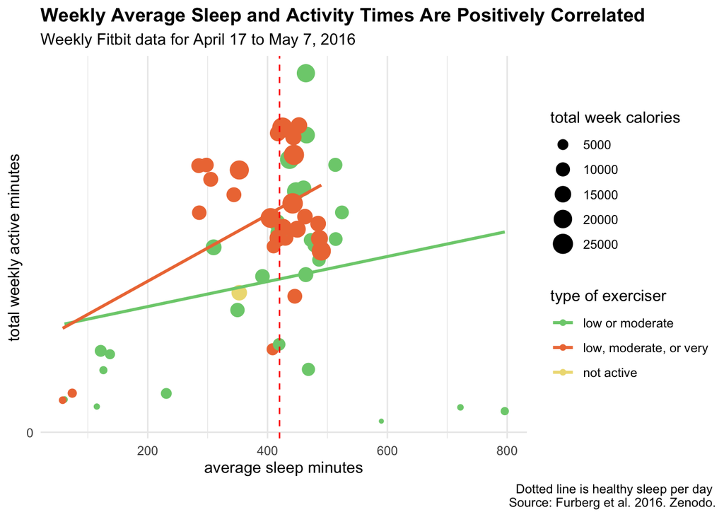

```r
# weekly active minutes vs. average sleep minutes
scatter.wk.sleepActiveMin <- wk.sleepActivity %>%
  ggplot(aes(x = avgSleepMin, y = wkActiveMin)) +
  geom_point(aes(color = user_type, size=totalCalories)) +
  geom_smooth(method="lm", se = FALSE, alpha = 0.2, aes(color = user_type)) +
  geom_vline(xintercept = 420, linetype = "dashed", color = "red") +
  ggtitle("Weekly Average Sleep and Activity Times Are Positively Correlated") +
  scale_y_continuous(breaks = seq(0, 28000, 4000)) +
  scale_color_manual(values = c("palegreen3", "sienna2", "lightgoldenrod2"), labels= c("low or moderate", "low, moderate, or very", "not active")) +
  labs(subtitle = "Weekly Fitbit data for April 17 to May 7, 2016", x = "average sleep minutes", y = "total weekly active minutes", size = "total week calories", color = "type of exerciser", caption = "Dotted line is healthy sleep per day \nSource: Furberg et al. 2016. Zenodo.") +
  theme_minimal() +
  theme(plot.caption.position = "plot",
        plot.title= element_text(face="bold"))
scatter.wk.sleepActiveMin
```

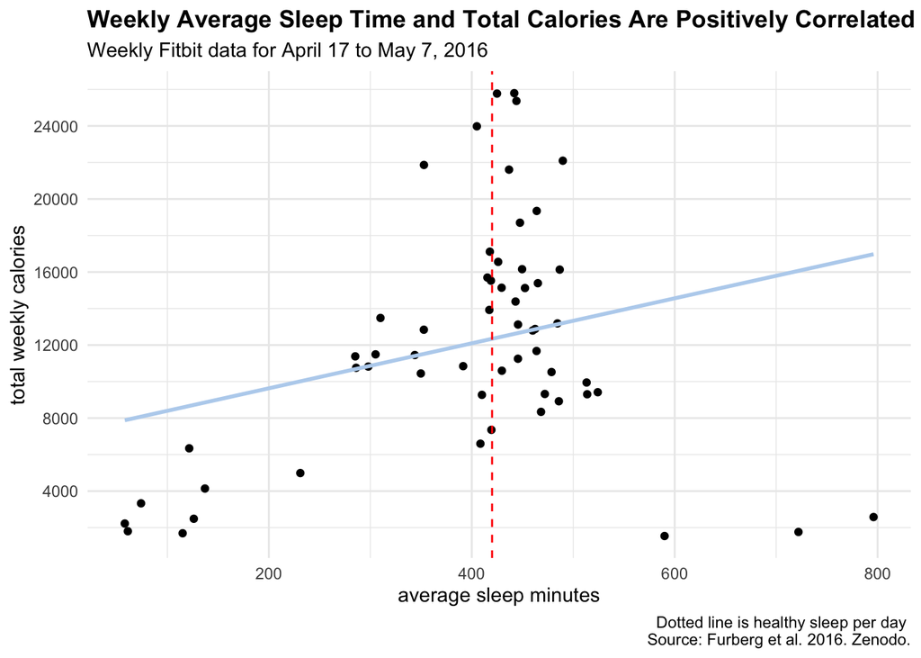

```r
# ggsave("./plots/scatter.wk.sleepActiveMin.png" , width = 10, height = 7, dpi=300)

# total weekly calories vs. average sleep minutes
scatter.wk.sleepCalories <- wk.sleepActivity %>%
  ggplot(aes(x = avgSleepMin, y = totalCalories)) +
  geom_point() +
  geom_smooth(method="lm", se = FALSE, color = "slategray2") +
  geom_vline(xintercept = 420, linetype = "dashed", color = "red") +
  ggtitle("Weekly Average Sleep Time and Total Calories Are Positively Correlated") +
  scale_y_continuous(breaks = seq(0, 28000, 4000)) +
  labs(subtitle = "Weekly Fitbit data for April 17 to May 7, 2016", x = "average sleep minutes", y = "total weekly calories", caption = "Dotted line is healthy sleep per day \nSource: Furberg et al. 2016. Zenodo.") +
  theme_minimal() +
  theme(plot.caption.position="plot",
        plot.title= element_text(face="bold"))
scatter.wk.sleepCalories
```

```r
# ggsave("./plots/scatter.wk.sleepCalories.png" , width = 10, height = 7, dpi=300)
```

#### Key Findings – Sleep and exercise activity

More sleep is positively correlated with more exercise and calorie burning, by week. If Bellabeat Time users are provided daily reminders to meet sleep targets (7+ hours / day), that could in turn, improve their exercise activity.

## Summary of Project Analysis

For this case study, I analyzed Fitbit data related to **activity** and **sleep** to examine trends among fitness tracking users, to then inform insights for improving the Bellabeat Time fitness watch, which is designed to track user activity and sleep patterns, among other measures.

### Activity

I analyzed *daily activity* data related to activity intensities (very, moderate, and lightly active), calories, and steps. By determining whether or not users achieved healthy light/moderate or very active times per week and how frequently they met those goals (a majority of weeks being at least 2 of 3 weeks), I found two main groups of exercisers:

- Light/moderate exercisers (but not very active) – LM
- light/moderate and very active exercisers – LMV

Then, I looked at *hourly activity* data, using this same grouping of exerciser types. I examined when people most frequently exercised, based on average total intensities by hour and day of the week and determined separate trends for different types of exercisers, along with trends for the overall users.

### Sleep

For the *sleep day* data, I analyzed the following and found these *trends*:

- How often were users recording sleep data?
  - Fewer than 20% of users consistently recorded sleep data over three weeks
- How often were users getting a healthy amount of sleep each day (at least 7 hours), of the total days they recorded sleep data?
  - Fewer than a quarter of users had at least 75% days of healthy sleep
  - Over a quarter of users had only less than 25% days of healthy sleep
- By merging the sleep and activity data and visualizing total weekly active minutes and average sleep minutes per week, there is a slightly positive correlation between sleep and activity for exercisers of either intensity group (LMV or LM).

### Data Limitations

The data used for this analysis was limited to a small sample size (around 30 or fewer users).

In particular, the sleep dataset had information for fewer than 30 users. The sleep trends found from this data analysis are not a significant representation of a larger population, due to the small sample population and missing data.

As the data collected was for a short time period, between April and May 2016, the health activity and sleep patterns are limited to an optimal season of exercise (spring/fall, depending on the hemisphere location of each user). Activity and sleep trends could vary during other seasons of the year.

Due to the anonymity of user Ids, no information was known about users’ biological sex or age, nor work hours, living conditions, and class status, characteristics which could impact a person’s exercise and sleep schedules.

### Act – High-level Recommendations for Stakeholders

The following recommendations are based on trends from the analysis and can be applied to Bellabeat’s fitness tracking watch, Time.

**Activity tracking suggestions**

- Provide a questionnaire for users to determine the type of intensity workouts they plan on doing regularly and an option to set weekly exercise goals
- Provide a weekly summary graph to show times of activity intensity per day and weekly totals per type of intensity (light/moderate and very active)
- Include a reminder of optimal intensity exercise goals during the week and the difference of time needed to complete that weekly goal, based on exercise intensity time already spent
- Give users the option to create hourly exercise schedules with reminder notifications
- Suggest optimal exercise hours based on the type of exercise they intend on doing, as answered in their questionnaire

**Sleep tracking suggestions**

- Create an optional sleeping tracking ring to act as a companion to the Time watch. The ring is a smaller wearable option that could encourage users to wear a tracking device daily when sleeping.
- Provide the option of daily notifications to remind users to wear the watch while sleeping
- Allow users to select optimal sleep and waking times and set reminders to go to bed by that certain time
- Inform users of the benefits of healthy amounts of sleep, correlated with more weekly exercise

## References

The following references are organized into sections by order of appearance.

#### Data, Background Information

1. Furberg, R., Brinton, J., Keating, M., & Ortiz, A. (2016). *Crowd-sourced Fitbit datasets 03.12.2016-05.12.2016*. [Data set]. Zenodo. https://doi.org/10.5281/zenodo.53894. Retrieved from https://www.kaggle.com/arashnic/fitbit.
2. Fitabase. (2018). *Fitabase Data Dictionary*. Retrieved from https://www.fitabase.com/media/1930/fitabasedatadictionary102320.pdf
3. National Health Interview Survey (NHIS), Centers for Disease Control and Prevention (CDC) / National Center for Health Statistics (NCHS). (2022). *Physical Activity.* Retrieved from https://www.healthypeople.gov/2020/topics-objectives/topic/physical-activity/national-snapshot.
4. CDC. (2022) *Physical Activity*. Retrieved from https://www.cdc.gov/physicalactivity/basics/adults/index.htm.
5. Watson NF, Badr MS, Belenky G, et al. Recommended amount of sleep for a healthy adult: a joint consensus statement of the American Academy of Sleep Medicine and Sleep Research Society. Sleep. 2015;38(6):843–844. http://dx.doi.org/10.5665/sleep.4716.

#### Coding Resources

1. Soni, Yash. (2018) *How I analyzed the data from my Fitbit to improve my overall health. freeCodeCamp*. https://www.freecodecamp.org/news/how-i-analyzed-the-data-from-my-fitbit-to-improve-my-overall-health-a2e36426d8f9/.
2. Kassambara, Alboukadel. *ggcorrplot: Visualization of a correlation matrix using ggplot2* (0.1.3). https://rpkgs.datanovia.com/ggcorrplot/.
3. Holtz, Yan. (2018) *Violin plot with included boxplot and sample size in ggplot2*. The R Graph Gallery. https://www.r-graph-gallery.com/violin_and_boxplot_ggplot2.html.
4. Kamvar, Zhian N. (2021) *Package aweek: Convert Dates to Arbitrary Week Definitions*(1.02). Retrieved from https://cran.r-project.org/web/packages/aweek/aweek.pdf.
5. Li, Deanna. (2020) *Basic R Guide for NSC Statistics, Chapter 19: Scatterplots and Best Fit Lines - Two Sets*. (Bookdown) https://bookdown.org/dli/rguide/scatterplots-and-best-fit-lines-two-sets.html.
6. Holtz, Yan. (2018). *ggplot2 heatmap*. The R Graph Gallery. https://www.r-graph-gallery.com/79-levelplot-with-ggplot2.html.
7. Holtz, Yan. (2018). *R Color Brewer’s Palettes*. https://www.r-graph-gallery.com/38-rcolorbrewers-palettes.html.
8. Neitmann, Thomas. (2020) *Transform a ggplot2 Axis to a Percentage Scale*. https://thomasadventure.blog/posts/ggplot2-percentage-scale/.
9. Wickham, Hadley and Seidel, Dana. (2020) *Package scales: Scale Functions for Visualization*(1.1.1). https://cran.r-project.org/web/packages/scales/scales.pdf.
10. roelpeters.be. (2019) *Add percentages to your axes in R’s ggplot2 (and set the limits)*. https://www.roelpeters.be/add-percentages-to-your-axes-in-rs-ggplot2-and-set-the-limits/.
11. rcs. (2012) *How to put labels over geom_bar for each bar in R with ggplot2*. Stack Overflow. https://stackoverflow.com/questions/12018499/how-to-put-labels-over-geom-bar-for-each-bar-in-r-with-ggplot2.